# Wine Ratings Project - Natural Language Processing

Prasanna Soni

November 23, 2019

The main goal of this report will be to create a machine learning model that minimizes the **Root Mean Square Error** of our predictions. The **RMSE** can be computed as follows:

$$\mbox{RMSE} = \sqrt{\frac{1}{N} \sum_{c,t,v,w,va,p}^{} \left( \hat{y}_{c,t,v,w,va,p} - y_{c,t,v,w,va,p} \right)^2 }$$

We define $y_{c,t,v,w,va,p}$ as the true rating for country $c$, by taster $t$, of vintage $v$, from grape variety $va$ produced in province $p$, and denote our prediction with $\hat{y}_{c,t,v,w,va,p}$. $N$ is the number of predictions we make in a dataset.

Let us create a formula that automatically calculates the **RMSE**.

```r
RMSE <- function(true_ratings, predicted_ratings){
    sqrt(mean((true_ratings - predicted_ratings)^2))
  }
```

#loading all required Libraries

This report will contain three main sections.

First, we will use the **Creating the Datasets** section as an opportunity to set up the various datasets that we will be using throughout this report. There will be 3 main datasets:

1. **rating**: This contains all rows from the two sets below. This is the only set that will be created in this section. The other two will be created when we start our modelling exercise in the **Methods and Analysis** section.
2. **test_set**: This will be our final test set. We will not reference to it until we are ready to test our model and report our final RMSE, on which we will be graded. This will represent 10% of the data.
3. **train_set**: This is the bulk of the data, on which we will be performing our analysis. It represents about 90% of the data. We will act as thought this was this only data available, and train our models on this dataset.

Second, in the **Methods and Analysis** section, we will describe the process we use to create our rating system, but we will first do a bit of exploratory data analysis to better understand the data set. We will then turn our attention to the modelling of the problem, which we will explain in detail in the hopes that the reader can easily follow our thoughts.

Third, we will use the model created in the previous section to make predictions on the **testing_set** set. We will then proceed to calculate our final **RMSE**. This is the **Results** section.

##Creating the Data Sets

```r
ratings <- read.csv("D:/Individual Project/winemag-data-130k-v2.csv")
```

Although we will need a training and a testing set, we wait until all our manipulations have occurred before creating them.

##Methods and Analysis

####Exploratory Data Analysis and Visualization of non-NLP variables

Before diving into the machine learning exercises, it is important to understand the data we are using. In this section, we will dive into the details of the data that is available to us.

| Variables | Description |
| --- | --- |
| X | Row Identifier |
| country | Country of origin of the wine |
| description | The full text of the review written by the taster |
| designation | The vineyard within the winery where the grapes that made the wine are from |
| points | The number of points WineEnthusiast rated the wine on a scale of 1-100 (though they say they only post reviews for wines that score >=80) |
| price | The cost for a bottle of the wine |
| province | The province or state that the wine is from |
| region_1 | The wine growing area in a province or state (ie Napa) |
| region_2 | Sometimes there are more specific regions specified within a wine growing area (ie Rutherford inside the Napa Valley), but this value can sometimes be blank |
| taster_name | Name of the taster |
| taster_twitter_handle | Twitter Handle of the taster |
| title | The title of the wine review |
| variety | The type of grapes used to make the wine (ie Pinot Noir) |
| winery | The winery that made the wine |

Let’s now explore some of these variables.

#####Country

Let us now turn our attention to which countries are represented.

We can compute how many different countries are represented.

```r
length(unique(ratings$country))
```

```
## [1] 44
```

We can make a bar plot showing the number of reviews by country like this (for the top 10).

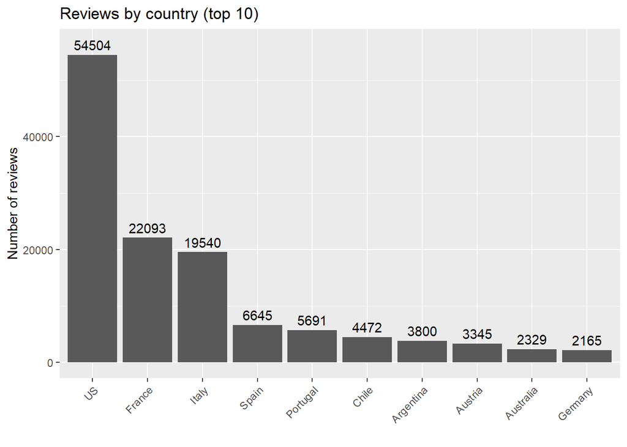

```r
ratings %>% group_by(country) %>% summarize(n=n()) %>% top_n(10,wt=n) %>%
  ggplot(aes(x=reorder(country,-n),y=n)) +
  geom_bar(stat="identity")+
  geom_text(aes(label=n),nudge_y = 1800)+
  labs(title="Reviews by country (top 10)", y="Number of reviews", x="")+
  theme(axis.text.x = element_text(angle = 45, hjust = 1))
```

We see that this is a very US-centric dataset, with about 42% of the reviews.

We can also have a quick look at the distribution of scores by country. We notice that Austria and Germany have very high median scores and that Spain and Chile take the bottom two spots in the top 10 countries with most reviews. Additionally, in the top 10, we notice that only 5 countries have a review of 100 points: Australia, France, Italy, Portugal and the US.

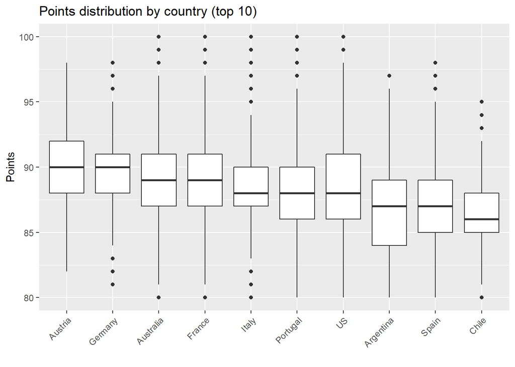

```r
top_10_countries <- ratings %>% group_by(country) %>% summarize(n=n()) %>% top_n(10,wt=n) %>% .$country

ratings %>% filter(country %in% top_10_countries) %>%
  ggplot(aes(x=reorder(country,-points,FUN = median), y=points)) +
  geom_boxplot()+
  labs(title="Points distribution by country (top 10)", y="Points", x="")+
  theme(axis.text.x = element_text(angle = 45, hjust = 1))
```

#####Points

As we are primarly interested about the points given to each wine, let us now examine the distribution of points.

Let’s first look at a few statistics:

```r
ratings %>% select(points) %>%
  summarize(Min=min(points),
            Max=max(points),
            Average=round(mean(points),2),
            Median=round(median(points),2),
            "Standard Deviation"=round(sd(points),2)) %>%
  kable(caption = "Points Statistics", align = rep("c",5)) %>%
  kable_styling(full_width = FALSE)
```

Points Statistics

| Min | Max | Average | Median | Standard Deviation |
| --- | --- | --- | --- | --- |
| 80 | 100 | 88.45 | 88 | 3.04 |

We can get a better understanding of the distribution by looking at a histogram.

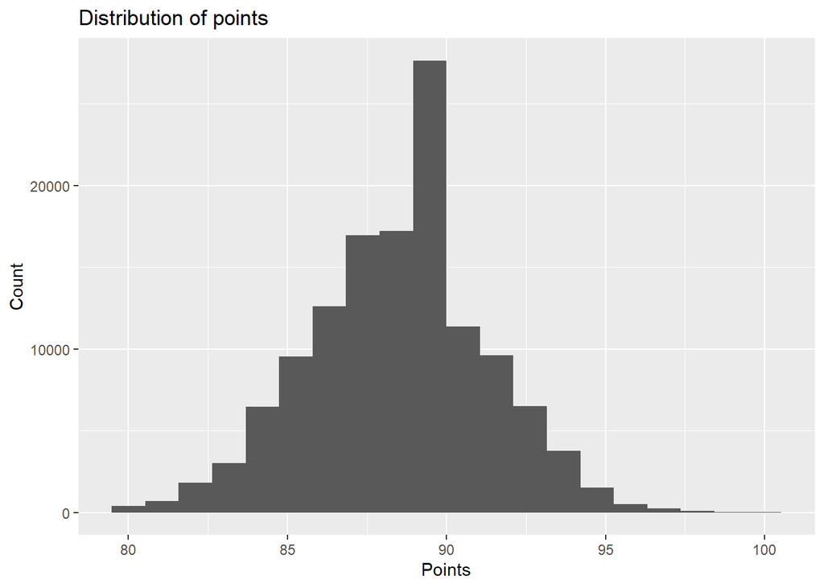

```r
ratings %>% select(points) %>%
  ggplot(aes(points)) +
  geom_histogram(bins = 20)+
  labs(title="Distribution of points", x="Points", y="Count")
```

We can check if the data is normally distributed with this code:

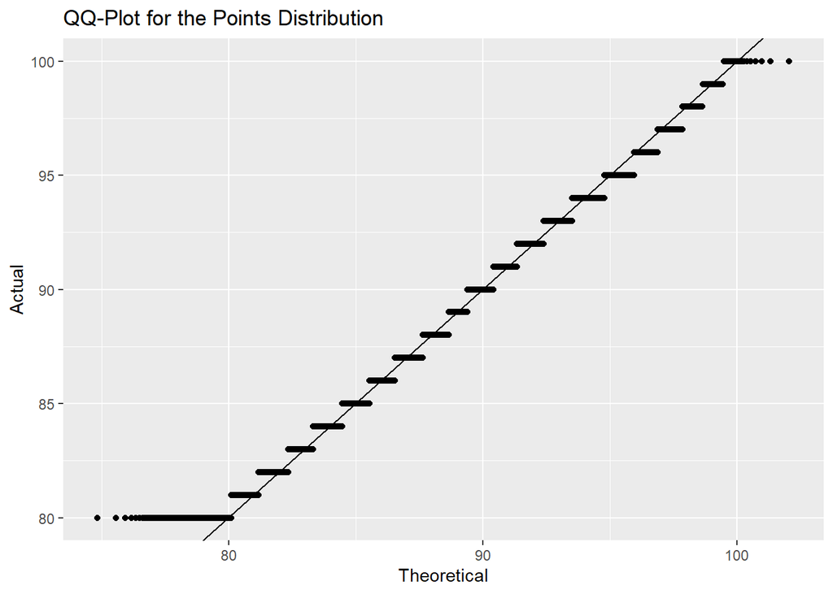

```r
ratings %>% ggplot(aes(sample=points)) +
  geom_qq(dparams=summarize(ratings, mean=mean(points), sd=sd(points))) +
  geom_abline() + labs(title="QQ-Plot for the Points Distribution", y="Actual", x="Theoretical")
```

We see from this plot that, although the data starts at 80 points and ends at 100 points, the normal distribution is a relatively good estimate between those two end points.

#####Price

Let us now look at the price variable, which is the only numerical variable we have at our disposal, thus far, to build our model. Let’s look at a distribution.

```r
ratings %>% filter(price != "") %>%
  summarize(Min=min(price),
            Max=max(price),
            Average=round(mean(price),2),
            Median=round(median(price),2),
            "Standard Deviation"=round(sd(price),2)) %>%
  kable(caption = "Price Statistics", align = rep("c",5)) %>%
  kable_styling(full_width = FALSE)
```

Price Statistics

| Min | Max | Average | Median | Standard Deviation |
| --- | --- | --- | --- | --- |
| 4 | 3300 | 35.36 | 25 | 41.02 |

We can build a histogram to get a better view.

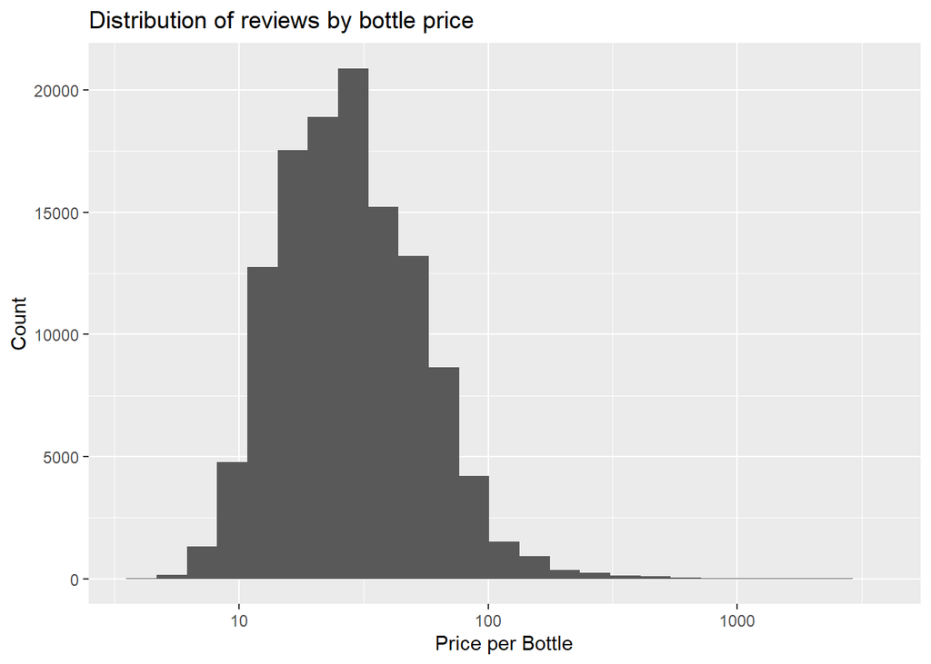

```r
ratings %>% filter(price != "") %>%
  ggplot(aes(price)) +
  geom_histogram(bins=25)+
  scale_x_log10()+
  labs(title="Distribution of reviews by bottle price", y="Count", x="Price per Bottle")
```

Now, the question on everyone’s lip is whether there is a correlation between price and quality (points). Let’s look at a scatterplot.

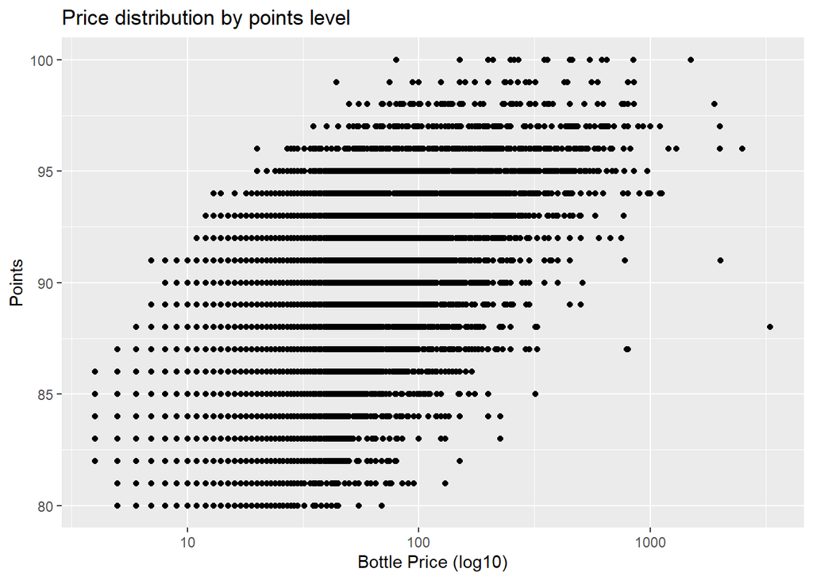

```r
ratings %>% filter(price !="") %>%
  ggplot(aes(x=price,y=points))+
  geom_point()+
  scale_x_log10()+
  labs(title="Price distribution by points level", y="Points", x="Bottle Price (log10)")
```

We can see from this graph that there does seem to be a slight correlation, with most of the very low scores in the low-end of the price range. We also notice how, as we go up in points, we tend to shift to the right ot the price range.

To better understand this phenomenon, let’s look at the average price at each point level.

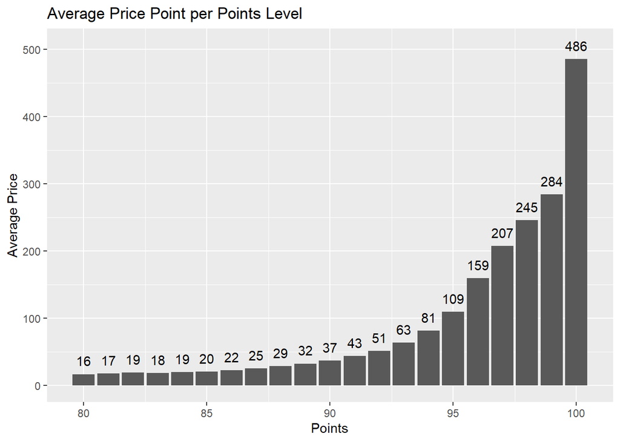

```r
ratings %>% filter(price != "") %>% group_by(points) %>%
  summarise(`Average Price`=mean(price)) %>%
  ggplot(aes(x=points, y=`Average Price`)) +
  geom_bar(stat = "identity")+
  geom_text(aes(label=round(`Average Price`)),nudge_y = 20)+
  labs(title="Average Price Point per Points Level", x="Points")
```

Here, we clearly see that bottles over and above 90 points tend to be much more expensive. On average, bottles with 95+ points cost more than $100. Only very expensive bottles receive 100 points.

#####Province

Most of the time, however, knowing the country and price of a wine isn’t sufficient to determine what to expect. For instance, a Côte-du-Rhone from France can be expected to taste very different from a Bordeaux or a Burgundy, and therefore affect the ratings..

Let us see which *provinces* are the most prevalent in our data.

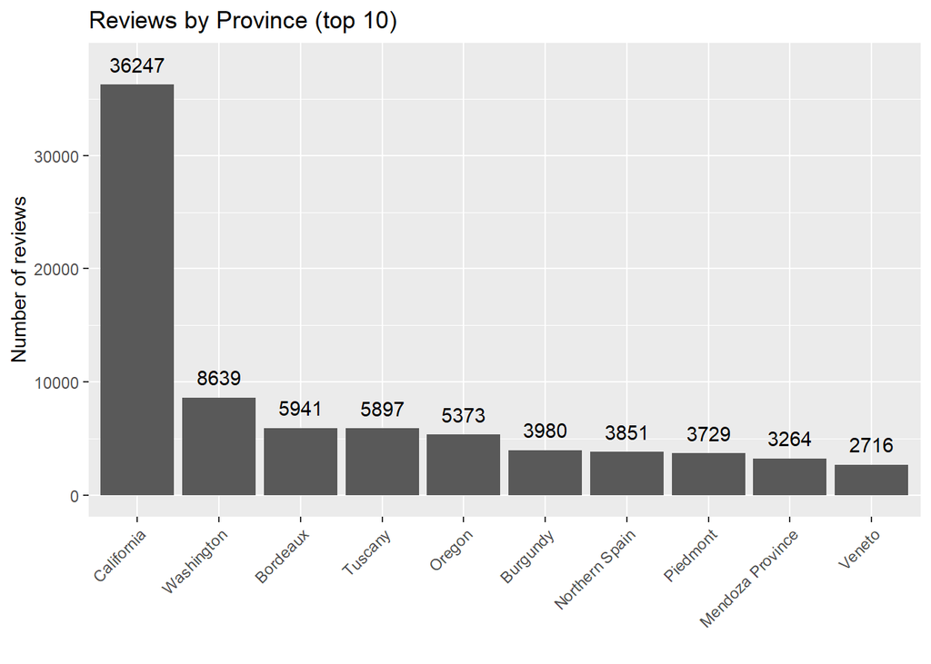

```r
ratings %>% group_by(province) %>% summarize(n=n()) %>% top_n(10,wt=n) %>%
  ggplot(aes(x=reorder(province,-n),y=n)) +
  geom_bar(stat="identity")+
  geom_text(aes(label=n),nudge_y = 1800)+
  labs(title="Reviews by Province (top 10)", y="Number of reviews", x="")+
  theme(axis.text.x = element_text(angle = 45, hjust = 1))
```

Again, we notice how skewed our data is towards the US, with California in particular. Within California, we see Napa, Russian River Valley, Paso Robles and Sonoma have a very strong showing. Weirdly enough, “California” appear again in this variable.

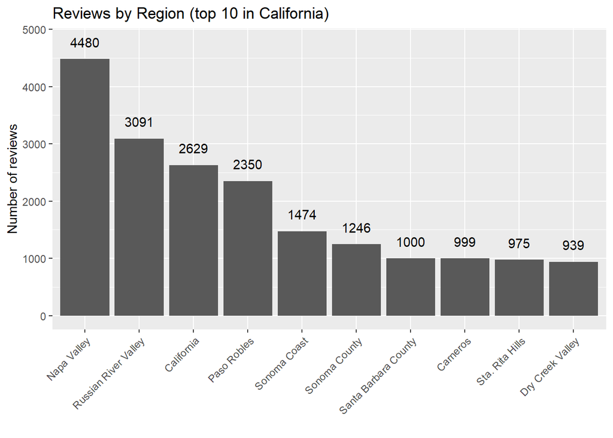

```r
ratings %>% filter(province=="California") %>%
  group_by(region_1) %>% summarize(n=n()) %>% top_n(10,wt=n) %>%
  ggplot(aes(x=reorder(region_1,-n),y=n)) +
  geom_bar(stat="identity")+
  geom_text(aes(label=n),nudge_y = 300)+
  labs(title="Reviews by Region (top 10 in California)", y="Number of reviews", x="")+
  theme(axis.text.x = element_text(angle = 45, hjust = 1))
```

Back to the whole dataset, let’s examine the score distribution by province for the top 10.

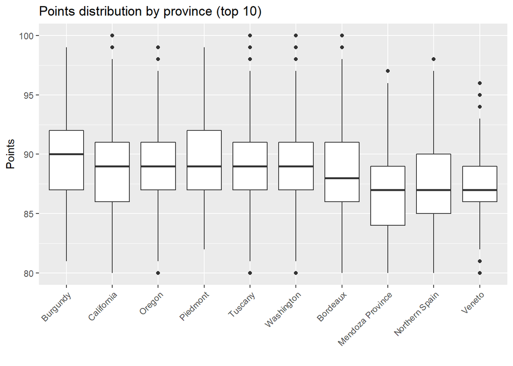

```r
top_10_province <- ratings %>% group_by(province) %>% summarize(n=n()) %>% top_n(10,wt=n) %>% .$province

ratings %>% filter(province %in% top_10_province) %>%
  ggplot(aes(x=reorder(province,-points,FUN = median), y=points)) +
  geom_boxplot()+
  labs(title="Points distribution by province (top 10)", y="Points", x="")+
  theme(axis.text.x = element_text(angle = 45, hjust = 1))
```

#####Taster

The next variable we will examine is who exactly wrote the review. This information is held in the **taster_name** variable.

There are 20 unique values in this variable, one of which is the absence of the rater’s name. We will exclude those observations in the following analysis.

Let us see who was most prolific.

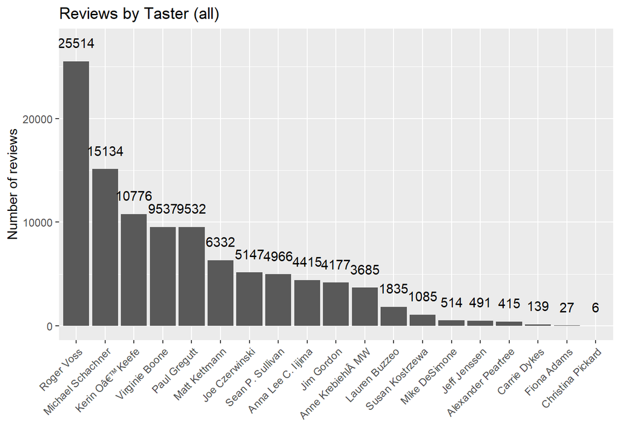

```r
ratings %>% filter(taster_name != "") %>% group_by(taster_name) %>% summarize(n=n()) %>%
  ggplot(aes(x=reorder(taster_name,-n),y=n)) +
  geom_bar(stat="identity")+
  geom_text(aes(label=n),nudge_y = 1800)+
  labs(title="Reviews by Taster (all)", y="Number of reviews", x="")+
  theme(axis.text.x = element_text(angle = 45, hjust = 1))
```

We can appreciate that Roger Voss, Michael Schadner and Kerin O’Keefe have a very strong contribution to the dataset. Especially Mr. Voss… that is a lot of wine.

Let us look now at a distribution of score by taster. We will only use the top 10 at this stage.

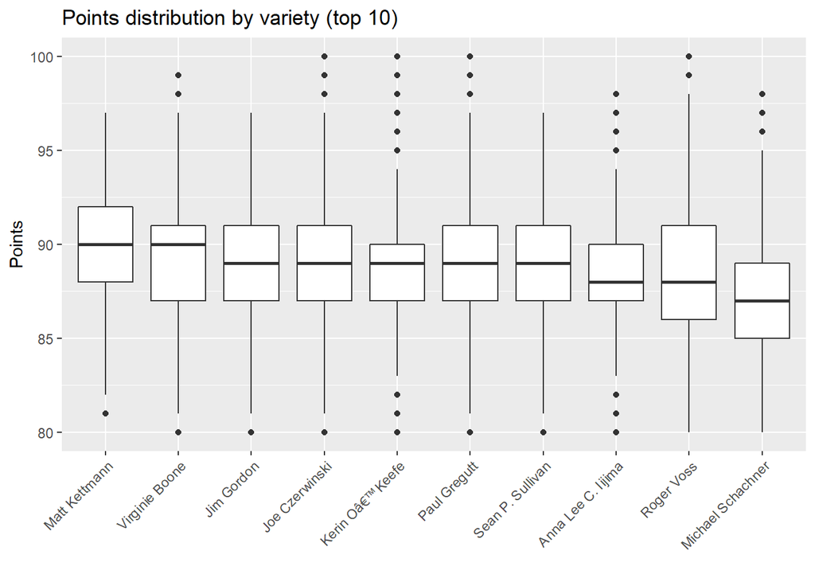

```r
top_10_taster <- ratings %>% filter(taster_name!="") %>% group_by(taster_name) %>% summarize(n=n()) %>% top_n(10,wt=n) %>% .$taster_name

ratings %>% filter(taster_name %in% top_10_taster) %>%
  ggplot(aes(x=reorder(taster_name,-points,FUN = median), y=points)) +
  geom_boxplot()+
  labs(title="Points distribution by variety (top 10)", y="Points", x="")+
  theme(axis.text.x = element_text(angle = 45, hjust = 1))
```

From this graph, we can see that some tasters tend to grade wines higher (like Matt Kettmann), and others more hasrshly (like Roger Voss and Michael Schachner).

#####Vintage

From the title of the review, we are often able to extract the vintage of the wine that was tasted.

Let us try to do this systematically. This analysis will not be perfect, but wil give us a very good idea nevertheless.

```r
year_pattern <- "\\d\\d\\d\\d"
ratings <- ratings %>% mutate(Vintage = as.numeric(str_extract(title,year_pattern)))

# Remove anything that could be an error. We will assume that no wine in the dataset was made before 1910.
ratings$Vintage <-  ifelse(ratings$Vintage>2018,"",ratings$Vintage)
ratings$Vintage <-  ifelse(ratings$Vintage<1910,"",ratings$Vintage)

# Create decades to make visualization easier

ratings <- ratings %>%
  mutate(Decade =
           ifelse(ratings$Vintage %in% 1900:1909, "1900s",
           ifelse(ratings$Vintage %in% 1910:1919, "1910s",
           ifelse(ratings$Vintage %in% 1920:1929, "1920s",
           ifelse(ratings$Vintage %in% 1930:1939, "1930s",
           ifelse(ratings$Vintage %in% 1940:1949, "1940s",
           ifelse(ratings$Vintage %in% 1950:1959, "1950s",
           ifelse(ratings$Vintage %in% 1960:1969, "1960s",
           ifelse(ratings$Vintage %in% 1970:1979, "1970s",
           ifelse(ratings$Vintage %in% 1980:1989, "1980s",
           ifelse(ratings$Vintage %in% 1990:1999, "1990s",
           ifelse(ratings$Vintage %in% 2000:2009, "2000s",
           ifelse(ratings$Vintage %in% 2010:2019, "2010s",
                  "")))))))))))))
```

The above code added two variables to our dataset: Vintage and Decade.

Let’s now look at this last variable:

```r
ratings %>% filter(Decade != "") %>% group_by(Decade) %>%
  summarise(Reviews = n(), `Average Score`=round(mean(points),2)) %>%
  kable(align = rep("c",3)) %>%
  kable_styling(full_width = FALSE)
```

| Decade | Reviews | Average Score |
| --- | --- | --- |
| 1910s | 9 | 89.89 |
| 1920s | 8 | 88.12 |
| 1930s | 2 | 93.50 |
| 1940s | 3 | 93.67 |
| 1950s | 3 | 95.33 |
| 1960s | 12 | 94.17 |
| 1970s | 5 | 90.80 |
| 1980s | 28 | 90.86 |
| 1990s | 1661 | 87.99 |
| 2000s | 37896 | 88.24 |
| 2010s | 85566 | 88.60 |

Although earlier decades seem to display higher scores, this is likely due to the fact that there are only a few reviews for these years, of very good bottles.

For curiosity, let’s look at the average score for the region of Bordeaux for the years 2005+. For anyone with wine knowledge, the results won’t be surprising: 2009, 2008 and 2010 are very high on the list. I must say that 2015 being second to last is unexpected however.

```r
ratings %>% filter(Vintage>2005 & province=="Bordeaux") %>%
  group_by(Vintage) %>%
  summarize("Average Score"=round(mean(points),2), Reviews = n()) %>%
  arrange(-`Average Score`) %>%
  kable(align = rep("c",3)) %>%
  kable_styling(full_width = F)
```

| Vintage | Average Score | Reviews |
| --- | --- | --- |
| 2009 | 90.18 | 473 |
| 2008 | 89.75 | 287 |
| 2010 | 89.40 | 733 |
| 2006 | 89.14 | 272 |
| 2007 | 88.94 | 179 |
| 2014 | 88.73 | 966 |
| 2012 | 88.67 | 824 |
| 2011 | 88.17 | 726 |
| 2013 | 87.85 | 506 |
| 2015 | 87.26 | 525 |
| 2016 | 86.64 | 218 |

#####Variety

Let us now turn our attention to which grape varietals are represented.

We can compute how many different grape varietals are represented.

```r
length(unique(ratings$variety))
```

```
## [1] 708
```

To the untrained eye, 708 may seem like a lot, but let us remember that there are approximately 10,000 grape varietals in the world. Of course, not all of them are frequently found in wine. Let’s look at the top 12 varieties.

```r
ratings %>%
  group_by(variety) %>%
  summarize(Reviews=n()) %>%
  top_n(12,Reviews) %>%
  arrange(desc(Reviews)) %>%
  select(Variety=variety,Reviews=Reviews) %>%
  kable(align = rep("c",2)) %>%
  kable_styling(full_width = FALSE)
```

| Variety | Reviews |
| --- | --- |
| Pinot Noir | 13272 |
| Chardonnay | 11753 |
| Cabernet Sauvignon | 9472 |
| Red Blend | 8946 |
| Bordeaux-style Red Blend | 6915 |
| Riesling | 5189 |
| Sauvignon Blanc | 4967 |
| Syrah | 4142 |
| RosÃ© | 3564 |
| Merlot | 3102 |
| Nebbiolo | 2804 |
| Zinfandel | 2714 |

We notice that the most common variety are Pinot Noir, Chardonnay and Cabernet Sauvignon. This is not surprising as those grapes are very common in the US. We then see “Red Blend” and “Bordeaux-style Red Blend”. The former is a bit dissapointing as Red Blend could litteraly mean anything. Let’s see where those wines come from:

```r
ratings %>% filter(variety=="Red Blend") %>%
  group_by(country) %>%
  summarize(Reviews =n()) %>%
  select(Country=country,Reviews=Reviews) %>%
  top_n(5,Reviews) %>%
  arrange(desc(Reviews)) %>%
  kable(align = rep("c",2)) %>%
  kable_styling(full_width = FALSE)
```

| Country | Reviews |
| --- | --- |
| Italy | 3624 |
| US | 2972 |
| Spain | 818 |
| Chile | 409 |
| France | 304 |

We are a bit surprised that Italy would have so many “Red Blends” since there are many *appelations* that would have made the data more specific. However, we are not surprised to see the US high on this list given the flexibility of winemaking regulations in the country.

For wines of the old world, France for instance, we expect to see specific blends. For instance, all wines in Bordeaux would have some concentration of Cabernet Sauvignon, Cabernet Franc and Merlot, and perhaps a bit of Petit Verdot. Let’s see.

```r
ratings %>% filter(province=="Bordeaux") %>%
  group_by(variety) %>%
  summarize(Reviews=n()) %>%
  select(Variety=variety,Reviews) %>%
  top_n(5,Reviews) %>%
  arrange(desc(Reviews)) %>%
  kable(align = rep("c",2)) %>%
  kable_styling(full_width = FALSE)
```

| Variety | Reviews |
| --- | --- |
| Bordeaux-style Red Blend | 4617 |
| Bordeaux-style White Blend | 951 |
| RosÃ© | 191 |
| Merlot | 72 |
| Sauvignon Blanc | 68 |

Our intuition is confirmed.

Let us now look at the top 10 varieties and their score distribution.

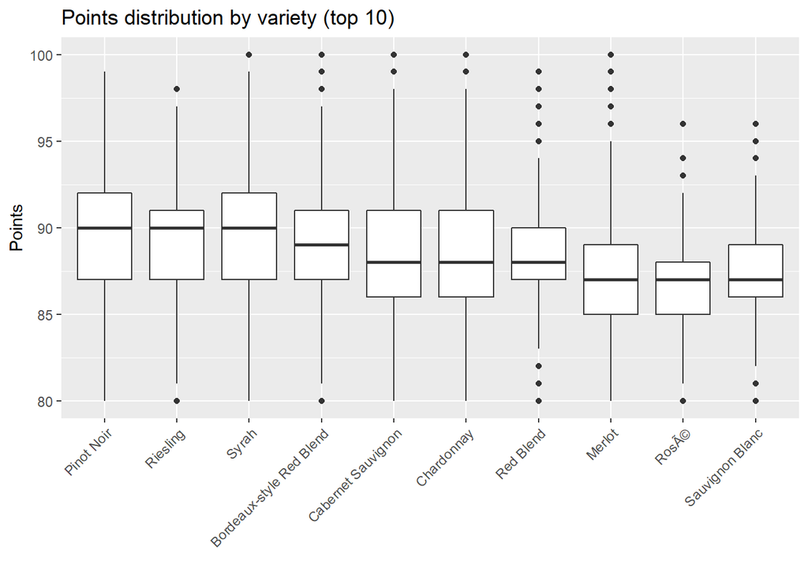

```r
top_10_varieties <- ratings %>% group_by(variety) %>% summarize(n=n()) %>% top_n(10,wt=n) %>% .$variety

ratings %>% filter(variety %in% top_10_varieties) %>%
  ggplot(aes(x=reorder(variety,-points,FUN = median), y=points)) +
  geom_boxplot()+
  labs(title="Points distribution by variety (top 10)", y="Points", x="")+
  theme(axis.text.x = element_text(angle = 45, hjust = 1))
```

#####Winery

We know that some wineries have a very strong reputation and tend to systematically attract more points. Let us look at the distribution of the average score by winery.

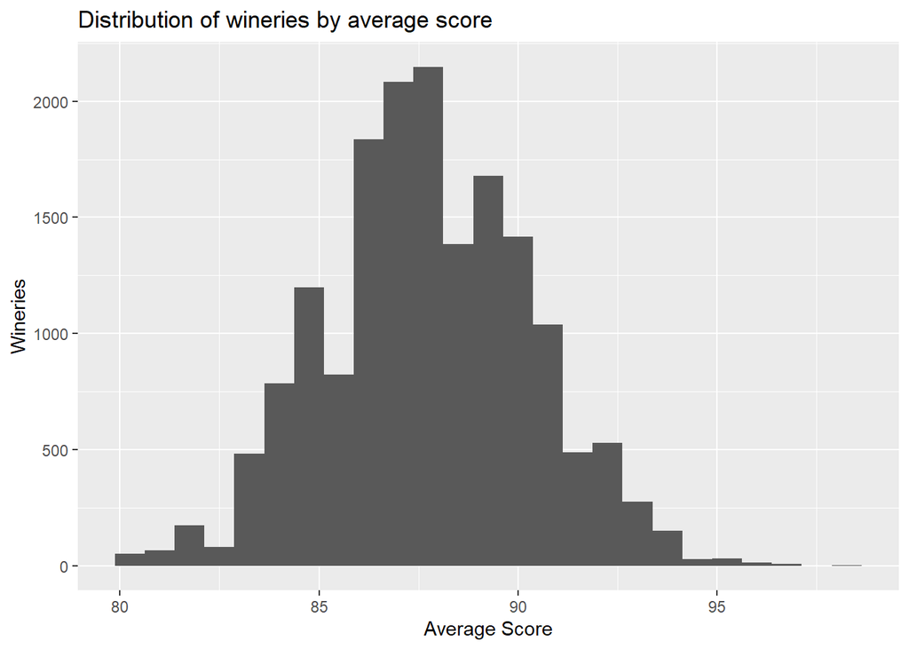

```r
ratings %>% group_by(winery) %>% summarize(Avg=mean(points)) %>%
  ggplot(aes(Avg)) +
  geom_histogram(bins=25)+
  labs(title="Distribution of wineries by average score", y="Wineries", x="Average Score")
```

Of course, it is possible that some of the extreme cases here are wineries that are only seldom reviewed. The average number of review per winery is:

```r
ratings %>% group_by(winery) %>% summarise(n=n()) %>% ungroup() %>% summarise(Average=mean(n)) %>% .$Average
```

```
## [1] 7.756221
```

```r
ratings %>% group_by(winery) %>%
  summarise(Avg=mean(points),Reviews=n(), Price = round(mean(price),2)) %>%
  filter(Avg>95 & Reviews>=8) %>% arrange(-Avg) %>%
  select(Winery=winery, `Average Score`=Avg, Reviews = Reviews, `Average Bottle Price`=Price) %>%
  kable(align = rep("c",3)) %>%
  kable_styling(full_width = F)
```

| Winery | Average Score | Reviews | Average Bottle Price |
| --- | --- | --- | --- |
| Tenuta dell’Ornellaia | 96.70000 | 10 | 286.50 |
| Château Léoville Barton | 95.66667 | 9 | NA |
| Wayfarer | 95.33333 | 18 | 111.67 |
| Mascarello Giuseppe e Figlio | 95.20000 | 10 | 174.30 |
| Horsepower | 95.09091 | 11 | 116.82 |

####NLP on the Description Variable

In the following section, we will dive into the content of the **description** variable, which contains the text of the review written by the tasters. We will use tecniques of text mining and natural language processing.

We now create a quick function to get rid of English contractions

```r
fix.contractions <- function(doc) {
  # "won't" is a special case as it does not expand to "wo not"
  doc <- gsub("won't", "will not", doc)
  doc <- gsub("can't", "can not", doc)
  doc <- gsub("n't", " not", doc)
  doc <- gsub("'ll", " will", doc)
  doc <- gsub("'re", " are", doc)
  doc <- gsub("'ve", " have", doc)
  doc <- gsub("'m", " am", doc)
  doc <- gsub("'d", " would", doc)
  # 's could be 'is' or could be possessive: it has no expansion
  doc <- gsub("'s", "", doc)
  return(doc)
}
```

Let’s apply it, and convert everything to lower case.

```r
ratings$description <- sapply(ratings$description,fix.contractions)
ratings$description <- tolower(ratings$description)
```

Let us now create a data frame in a tidy format, where each word has a row. We use the **udpipe** package to also lemmatize each word (e.g., aromas = aroma) and get its Part of Speech (e.g., adjective, noun, etc.). I anti-join the dataset *stop_words* to get rid of overly common words like “where”, “has”, “yet”, etc. Finally, I only keep words with 3 characters or more, since most small words do not reveal that much meaning.

Dataframe will consist of words from description

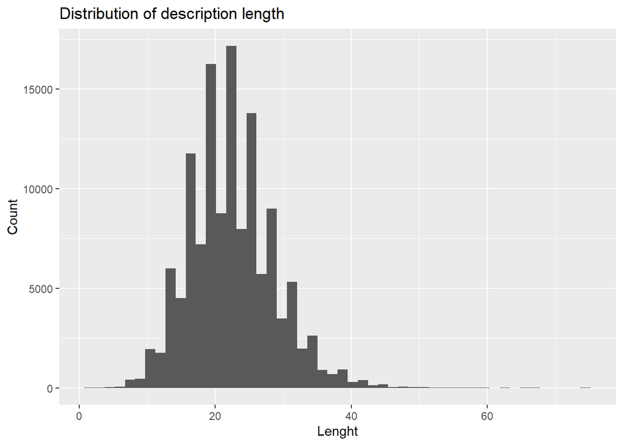

```r
library(udpipe)
load("D:/Individual Project/words_in_descriptions.rda")
length_of_decription <- words_in_descriptions %>% group_by(doc_id) %>% summarise(Length=n()) %>% mutate(X=as.integer(doc_id)) %>% select(X,Length)

length_of_decription %>% ggplot(aes(x=Length))+
  geom_histogram(bins=50)+
  labs(title="Distribution of description length",x="Lenght",y="Count")
```

Let us see if there seems to be a relationship between the length of the descriptions and the points.

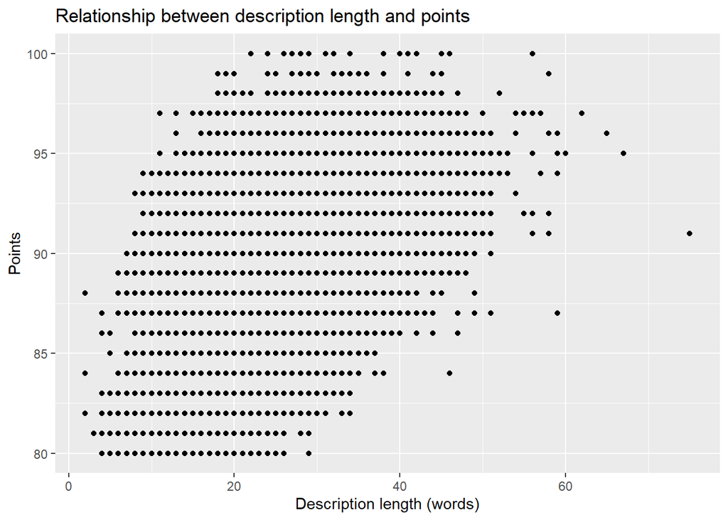

```r
# Adding the length of description as a variable in ratings
ratings <- ratings %>% left_join(length_of_decription,by = "X")

ratings %>% ggplot(aes(x=Length,y=points))+
  geom_point()+
  labs(title="Relationship between description length and points", x="Description length (words)", y="Points")
```

Next, let’s look at the most popular root words being used.

```r
words_in_descriptions %>% group_by(lemma) %>%
  summarise(Count=n()) %>%
  arrange(desc(Count)) %>%
  top_n(10,Count) %>%
  select(`Root Word`=lemma,Count) %>%
  kable(align = c("c","c")) %>%
  kable_styling(full_width = F)
```

| Root Word | Count |
| --- | --- |
| wine | 83095 |
| flavor | 69925 |
| fruit | 63864 |
| aroma | 40670 |
| finish | 39181 |
| palate | 38537 |
| acidity | 35000 |
| cherry | 33573 |
| drink | 33181 |
| tannin | 32971 |

Of course, the word wine and flavor appear quite a lot. After that, most of the common words are very important descriptors of wine. Apart from **aroma**, however, we notice that tasters mostly focus on the mouth elements of the wine, while the visual aspects and the nose are being left out slightly.

We can also take a look at what nouns and adjectives are often used together.

```r
cooc <- cooccurrence(x = subset(words_in_descriptions, upos %in% c("NOUN", "ADJ")),
                     term = "lemma",
                     group = c("doc_id", "paragraph_id", "sentence_id"))

kable(cooc[1:5,],align = rep("c",3)) %>%
  kable_styling(full_width = F)
```

| term1 | term2 | cooc |
| --- | --- | --- |
| flavor | fruit | 17681 |
| fruit | wine | 16809 |
| flavor | wine | 13269 |
| cherry | flavor | 12945 |
| black | cherry | 12212 |

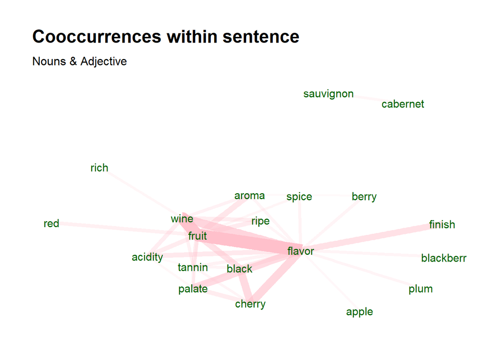

```r
wordnetwork <- head(cooc, 40)
wordnetwork <- graph_from_data_frame(wordnetwork)
ggraph(wordnetwork, layout = "fr") +
  geom_edge_link(aes(width = cooc, edge_alpha = cooc), edge_colour = "pink") +
  geom_node_text(aes(label = name), col = "darkgreen", size = 4) +
  theme_graph(base_family = "Arial") +
  theme(legend.position = "none") +
  labs(title = "Cooccurrences within sentence", subtitle = "Nouns & Adjective")
```

From the above, we can clearly see that it is very common for a wine to have cherry flavor or/and black fruit flavor. Other words that are often associated with flavor are: spice, finish (as in the wine’s finish), palate, ripe, acidity and tannins.

Let’s see which words are within the top 50 most common for bottles scoring 95+, but not within the top 50 for bottles scoring lower. These words may turn out to be very good predictors of a bottle’s score.

```r
words_in_descriptions <- words_in_descriptions %>% mutate(X=as.integer(doc_id)) %>%
  left_join(ratings, by = "X") %>% select(X,word,lemma,upos,points,price)

top_50_good <- words_in_descriptions %>% filter(points>=95) %>% group_by(lemma) %>%
  summarise(Count=n()) %>%
  arrange(desc(Count)) %>%
  top_n(50,Count)

top_50_lessthangood <- words_in_descriptions %>% filter(points<95) %>% group_by(lemma) %>%
  summarise(Count=n()) %>%
  arrange(desc(Count)) %>%
  top_n(50,Count)

good_predictor_words <- top_50_good %>% anti_join(top_50_lessthangood, by="lemma") %>% .$lemma

print(good_predictor_words)
```

```
##  [1] "age"       "vineyard"  "complex"   "vintage"   "firm"
##  [6] "dense"     "chocolate" "power"     "delicious" "powerful"
## [11] "time"      "richness"  "fine"      "currant"   "mineral"
## [16] "intense"   "layer"
```

Let us now create some more descriptors that relate to each descriptions, and add those to our **ratings** dataset. This is called “feature engineering”.

We add: lenght of descrition in words, the lexical diversity (distinct words), lexical density (diversity as % of total words), repetition (Length/diversity), number of large words with 8 or more characters, number of adjectives, number of nouns, number of verbs and, most importantly, number of words that are in the list of words typically associated with very good bottles as defined above.

```r
descriptors <- words_in_descriptions %>% group_by(X) %>%
  summarise(Length = n(),
            lexical_diversity = n_distinct(word),
            lexical_density = lexical_diversity/Length,
            repetition = Length/lexical_diversity,
            large_word_count = sum(ifelse((nchar(word) > 7), 1, 0)),
            adjectives_count = sum(ifelse(upos == "ADJ",1,0)),
            noun_count = sum(ifelse(upos == "NOUN",1,0)),
            verb_count = sum(ifelse(upos == "VERB",1,0)),
            good_words = sum(ifelse(lemma %in% good_predictor_words,1,0)))
```

We now add these descriptors to the **ratings** dataframe.

```r
#Adding the descriptors
ratings <- ratings %>% left_join(descriptors,by = "X")

#Cleaning the environment
rm(descriptors, words_in_descriptions)

#Selecting only the variables which we intend to use in our analysis and creating a ratings set for machine learning purposes

ratings_ML <- ratings %>%
  select(X,
         country,
         price,
         province,
         taster_name,
         variety,
         winery,
         Vintage,
         Lenght=Length.x,
         lexical_diversity,
         lexical_density,
         repetition,
         large_word_count,
         adjectives_count,
         noun_count,
         verb_count,
         good_words,
         points)

#Removing bottles for which price is not available

NAs <- which(is.na(ratings_ML$price))
ratings_ML <- ratings_ML[-NAs,]
```

####Modelling

We are now ready to use our data for Machine Learning purposes. We will begin by splitting our **ratings_ML** dataset into a **train_set** and a **test_set**.

```r
# Test set will be 10% of Ratings_ML data

set.seed(1)
test_index <- createDataPartition(y = ratings_ML$points, times = 1, p = 0.10, list = FALSE)
train_set <- ratings_ML[-test_index,]
temp_set <- ratings_ML[test_index,]

# Make sure country, province, taster_name, variety, winery and vintage are also in the training set

test_set <- temp_set %>%
      semi_join(train_set, by = "country") %>%
      semi_join(train_set, by = "province") %>%
      semi_join(train_set, by = "taster_name") %>%
      semi_join(train_set, by = "variety") %>%
      semi_join(train_set, by = "winery") %>%
      semi_join(train_set, by = "Vintage")

# Add rows removed from test set set back into train set

removed_rows <- anti_join(temp_set, test_set)
train_set <- rbind(train_set, removed_rows)

rm(removed_rows, temp_set, test_index)
```

Great, now, let’s give ourselves a benchmark. What if we predicted the average rating for each wine?

```r
average_rating <- mean(train_set$points)

naiveRMSE <- RMSE(test_set$points,average_rating)

rmse_results <- bind_rows(data_frame(Method = "Just the average", RMSE = naiveRMSE))

kable(rmse_results,align=rep("c",3)) %>%
  kable_styling(full_width = F) %>%
  column_spec(1,bold=T,border_right = T)
```

| Method | RMSE |
| --- | --- |
| Just the average | 3.045522 |

Here, we get a RMSE of about 3.0455. Not great. We are on average 3 full points away from the correct rating.

In this model, $\mu$ is the average rating in the training set.

#####Country Effect

We calculate it using this piece of code:

```r
country_avgs <- train_set %>%
  group_by(country) %>%
  summarize(country_effect = mean(points - average_rating))
```

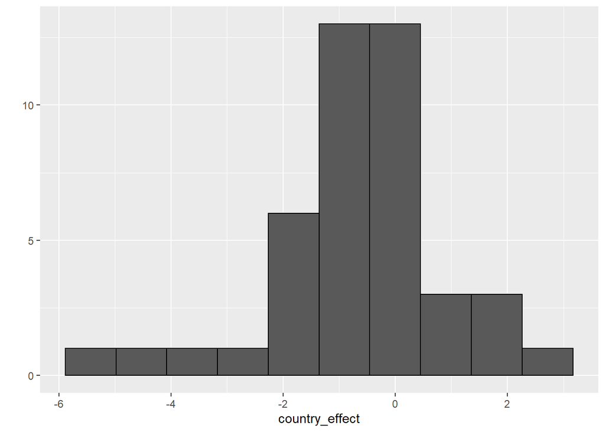

```r
country_avgs %>% qplot(country_effect, geom ="histogram", bins = 10, data = ., color = I("black"))
```

$$Y_{c,t,v,w,va,p} = \mu + \hat{b}_c + \varepsilon_{c,t,v,w,va,p}$$

```r
predicted_ratings <- average_rating + test_set %>%
  left_join(country_avgs, by='country') %>%
  .$country_effect

country_effect_RMSE <- RMSE(predicted_ratings, test_set$points)

rmse_results <- bind_rows(rmse_results,
                          data_frame(Method= "With Country Effect",
                                     RMSE=country_effect_RMSE))

kable(rmse_results,align=rep("c",3), caption = "Metrics calculated on test set only") %>%
  kable_styling(full_width = F) %>%
  column_spec(1,bold=T,border_right = T)
```

Metrics calculated on test set only

| Method | RMSE |
| --- | --- |
| Just the average | 3.045522 |
| With Country Effect | 2.973631 |

This is already an improvement. We could dive into regularization of this effect, but we decide not to here for the sake of expediency. Note that we have tried it on the side and it doesn’t help much.

#####Taster Effect

Now, we turn our attention to tasters. Some of them, as we saw before, tend to rate higher than others. Here we can calculate the **taster effect** which is a taster-specific effect once the **country effect** has been taken into consideration.

To be clear, this is the model we are trying, where $\mu$ is the average rating, $\hat{b}_c$ is the country effect, $\hat{b}_t$ is the taster effect and $\varepsilon_{c,t,v,w,va,p}$ is the error term:

$$Y_{c,t,v,w,va,p} = \mu + \hat{b}_c + \hat{b}_t+ \varepsilon_{c,t,v,w,va,p}$$

```r
taster_avgs <- train_set %>%
  left_join(country_avgs, by='country') %>%
  group_by(taster_name) %>%
  summarize(taster_effect = mean(points - average_rating - country_effect))
```

Let’s create predictions see how it improves our model.

```r
predicted_ratings <- test_set %>%
  left_join(country_avgs, by='country') %>%
  left_join(taster_avgs, by='taster_name') %>%
  mutate(pred = average_rating + country_effect + taster_effect) %>%
  .$pred

country_and_taster_effect <- RMSE(predicted_ratings, test_set$points)

rmse_results <- bind_rows(rmse_results,
                          data_frame(Method= "Country & Taster Effects",
                                     RMSE=country_and_taster_effect))


kable(rmse_results,align=rep("c",3), caption = "Metrics calculated on test set only") %>%
  kable_styling(full_width = F) %>%
  column_spec(1,bold=T,border_right = T)
```

Metrics calculated on test set only

| Method | RMSE |
| --- | --- |
| Just the average | 3.045522 |
| With Country Effect | 2.973631 |
| Country & Taster Effects | 2.906345 |

#####Vintage Effect

We now turn our attention to the vintage variable and make a similar analysis.

```r
vintage_avgs <- train_set %>%
  left_join(country_avgs, by='country') %>%
  left_join(taster_avgs, by = "taster_name") %>%
  group_by(Vintage) %>%
  summarize(vintage_effect = mean(points - average_rating - country_effect - taster_effect))

predicted_ratings <- test_set %>%
  left_join(country_avgs, by='country') %>%
  left_join(taster_avgs, by='taster_name') %>%
  left_join(vintage_avgs, by = 'Vintage') %>%
  mutate(pred = average_rating + country_effect + taster_effect+ vintage_effect) %>%
  .$pred

country_taster_vintage_effect_RMSE <- RMSE(predicted_ratings, test_set$points)

rmse_results <- bind_rows(rmse_results,
                          data_frame(Method= "Country & Taster & Vintage Effects",
                                     RMSE=country_taster_vintage_effect_RMSE))


kable(rmse_results,align=rep("c",3), caption = "Metrics calculated on test set only") %>%
  kable_styling(full_width = F) %>%
  column_spec(1,bold=T,border_right = T)
```

Metrics calculated on test set only

| Method | RMSE |
| --- | --- |
| Just the average | 3.045522 |
| With Country Effect | 2.973631 |
| Country & Taster Effects | 2.906345 |
| Country & Taster & Vintage Effects | 2.893075 |

At this point, we have completed our model, and only improved our RMSE by about 5%, which is not great. We are hopeful that the other variables will be helpful.

#####Winery Effect

We now turn our attention to the winery variable and make a similar analysis.

```r
winery_avgs <- train_set %>%
  left_join(country_avgs, by='country') %>%
  left_join(taster_avgs, by = "taster_name") %>%
  left_join(vintage_avgs, by = "Vintage") %>%
  group_by(winery) %>%
  summarize(winery_effect = mean(points - average_rating - country_effect - taster_effect - vintage_effect))

predicted_ratings <- test_set %>%
  left_join(country_avgs, by='country') %>%
  left_join(taster_avgs, by='taster_name') %>%
  left_join(vintage_avgs, by = 'Vintage') %>%
  left_join(winery_avgs,by='winery') %>%
  mutate(pred = average_rating + country_effect + taster_effect+ vintage_effect+winery_effect) %>%
  .$pred

country_taster_vintage_winery_effect_RMSE <- RMSE(predicted_ratings, test_set$points)

rmse_results <- bind_rows(rmse_results,
                          data_frame(Method= "Country & Taster & Vintage & Winery Effects",
                                     RMSE=country_taster_vintage_winery_effect_RMSE))


kable(rmse_results,align=rep("c",3), caption = "Metrics calculated on test set only") %>%
  kable_styling(full_width = F) %>%
  column_spec(1,bold=T,border_right = T)
```

Metrics calculated on test set only

| Method | RMSE |
| --- | --- |
| Just the average | 3.045522 |
| With Country Effect | 2.973631 |
| Country & Taster Effects | 2.906345 |
| Country & Taster & Vintage Effects | 2.893075 |
| Country & Taster & Vintage & Winery Effects | 2.385231 |

#####Variety Effect

We now turn our attention to the variety variable and make a similar analysis.

```r
variety_avgs <- train_set %>%
  left_join(country_avgs, by='country') %>%
  left_join(taster_avgs, by = "taster_name") %>%
  left_join(vintage_avgs, by = "Vintage") %>%
  left_join(winery_avgs, by = 'winery') %>%
  group_by(variety) %>%
  summarize(variety_effect = mean(points - average_rating - country_effect - taster_effect - vintage_effect - winery_effect))

predicted_ratings <- test_set %>%
  left_join(country_avgs, by='country') %>%
  left_join(taster_avgs, by='taster_name') %>%
  left_join(vintage_avgs, by = 'Vintage') %>%
  left_join(winery_avgs,by='winery') %>%
  left_join(variety_avgs,by='variety') %>%
  mutate(pred = average_rating + country_effect + taster_effect+ vintage_effect+winery_effect+variety_effect) %>%
  .$pred

country_taster_vintage_winery_variety_effect_RMSE <- RMSE(predicted_ratings, test_set$points)

rmse_results <- bind_rows(rmse_results,
                          data_frame(Method= "Country & Taster & Vintage & Winery & Variety Effects",
                                     RMSE=country_taster_vintage_winery_variety_effect_RMSE))


kable(rmse_results,align=rep("c",3), caption = "Metrics calculated on test set only") %>%
  kable_styling(full_width = F) %>%
  column_spec(1,bold=T,border_right = T)
```

Metrics calculated on test set only

| Method | RMSE |
| --- | --- |
| Just the average | 3.045522 |
| With Country Effect | 2.973631 |
| Country & Taster Effects | 2.906345 |
| Country & Taster & Vintage Effects | 2.893075 |
| Country & Taster & Vintage & Winery Effects | 2.385231 |
| Country & Taster & Vintage & Winery & Variety Effects | 2.351174 |

#####Province Effect

We now turn our attention to the province variable and make a similar analysis.

```r
province_avgs <- train_set %>%
  left_join(country_avgs, by='country') %>%
  left_join(taster_avgs, by = "taster_name") %>%
  left_join(vintage_avgs, by = "Vintage") %>%
  left_join(winery_avgs, by = 'winery') %>%
  left_join(variety_avgs,by='variety') %>%
  group_by(province) %>%
  summarize(province_effect = mean(points - average_rating - country_effect - taster_effect - vintage_effect - winery_effect - variety_effect))

predicted_ratings <- test_set %>%
  left_join(country_avgs, by='country') %>%
  left_join(taster_avgs, by='taster_name') %>%
  left_join(vintage_avgs, by = 'Vintage') %>%
  left_join(winery_avgs,by='winery') %>%
  left_join(variety_avgs,by='variety') %>%
  left_join(province_avgs,by="province") %>%
  mutate(pred = average_rating + country_effect + taster_effect+ vintage_effect+winery_effect+variety_effect+province_effect) %>%
  .$pred

country_taster_vintage_winery_variety_province_effect_RMSE <- RMSE(predicted_ratings, test_set$points)

rmse_results <- bind_rows(rmse_results,
                          data_frame(Method= "Country & Taster & Vintage & Winery & Variety & Province Effects",
                                     RMSE=country_taster_vintage_winery_variety_province_effect_RMSE))


kable(rmse_results,align=rep("c",3), caption = "Metrics calculated on test set only") %>%
  kable_styling(full_width = F) %>%
  column_spec(1,bold=T,border_right = T)
```

Metrics calculated on test set only

| Method | RMSE |
| --- | --- |
| Just the average | 3.045522 |
| With Country Effect | 2.973631 |
| Country & Taster Effects | 2.906345 |
| Country & Taster & Vintage Effects | 2.893075 |
| Country & Taster & Vintage & Winery Effects | 2.385231 |
| Country & Taster & Vintage & Winery & Variety Effects | 2.351174 |
| Country & Taster & Vintage & Winery & Variety & Province Effects | 2.348546 |

#####Machine Learning Algorithm

Below, we train linear regression to minimize the errors when predicting **points** using the predicted values as well as all remaining variables: the price of the bottle as well as the descriptors of the description obtained from our Natural Language Processing section.

```r
library(dplyr)
library(ggplot2)
library(stringr)
library(wordcloud)
library(tidyverse)
library(tidytext)
library(stringr)
library(tm)
library(SnowballC)
library(elasticnet)
library(caret)

# Create predictions for the training set
predicted_ratings_train <- train_set %>%
  left_join(country_avgs, by='country') %>%
  left_join(taster_avgs, by='taster_name') %>%
  left_join(vintage_avgs, by = 'Vintage') %>%
  mutate(pred = average_rating + country_effect + taster_effect+ vintage_effect) %>%.$pred

#Add predicted values to both sets
train_set <- train_set %>% mutate(predicted_ratings = predicted_ratings_train,
                                  epsilon = points - predicted_ratings_train)
test_set <- test_set %>% mutate(predicted_ratings=predicted_ratings,
                                epsilon = points - predicted_ratings)

#Train the model
glm_trained <- train(points ~ predicted_ratings+ price+Lenght+lexical_diversity+lexical_density+repetition+large_word_count+adjectives_count+noun_count+verb_count+good_words, method="glm", data = train_set )


#train lasso Model
lasso_trained <- train(points ~ predicted_ratings+ price+Lenght+lexical_diversity+lexical_density+repetition+large_word_count+adjectives_count+noun_count+verb_count+good_words, method="lasso",data = train_set)

#train rlm Model
rlm_trained <- train(points ~ predicted_ratings+ price+Lenght+lexical_diversity+lexical_density+repetition+large_word_count+adjectives_count+noun_count+verb_count+good_words, method="rlm",data = train_set)
```

Let’s now test whether this improves our results.

```r
glm_predicted_ratings <- predict(glm_trained,test_set)

glm_RMSE <- RMSE(glm_predicted_ratings, test_set$points)

rmse_results <- bind_rows(rmse_results,
                          data_frame(Method= "Linear Regression on Epsilon",
                                     RMSE=glm_RMSE))


kable(rmse_results,align=rep("c",3), caption = "Metrics calculated on test set only") %>%
  kable_styling(full_width = F) %>%
  column_spec(1,bold=T,border_right = T)
```

Metrics calculated on test set only

| Method | RMSE |
| --- | --- |
| Just the average | 3.045522 |
| With Country Effect | 2.973631 |
| Country & Taster Effects | 2.906345 |
| Country & Taster & Vintage Effects | 2.893075 |
| Country & Taster & Vintage & Winery Effects | 2.385231 |
| Country & Taster & Vintage & Winery & Variety Effects | 2.351174 |
| Country & Taster & Vintage & Winery & Variety & Province Effects | 2.348546 |
| Linear Regression on Epsilon | 2.062728 |

```r
lasso_predicted_ratings <- predict(lasso_trained,test_set)

lasso_RMSE <- RMSE(lasso_predicted_ratings, test_set$points)

rmse_results <- bind_rows(rmse_results,
                          data_frame(Method="Lasso Regression",
                                     RMSE=lasso_RMSE))

kable(rmse_results,align=rep("c",3), caption = "Metrics calculated on test set only") %>%
  kable_styling(full_width = F) %>%
  column_spec(1,bold=T,border_right = T)
```

Metrics calculated on test set only

| Method | RMSE |
| --- | --- |
| Just the average | 3.045522 |
| With Country Effect | 2.973631 |
| Country & Taster Effects | 2.906345 |
| Country & Taster & Vintage Effects | 2.893075 |
| Country & Taster & Vintage & Winery Effects | 2.385231 |
| Country & Taster & Vintage & Winery & Variety Effects | 2.351174 |
| Country & Taster & Vintage & Winery & Variety & Province Effects | 2.348546 |
| Linear Regression on Epsilon | 2.062728 |
| Lasso Regression | 2.061981 |

```r
rlm_predicted_ratings <- predict(rlm_trained,test_set)

rlm_RMSE <- RMSE(rlm_predicted_ratings, test_set$points)

rmse_results <- bind_rows(rmse_results,
                          data_frame(Method="svmLinear Regression",
                                     RMSE=rlm_RMSE))

kable(rmse_results,align=rep("c",3), caption = "Metrics calculated on test set only") %>%
  kable_styling(full_width = F) %>%
  column_spec(1,bold=T,border_right = T)
```

Metrics calculated on test set only

[output not shown]

##Results

This method further brought down our RMSE to 2.0627281. That is a total improvement of 32.27% over our naive method of forecasting the average.

What’s more, we’ve also uncovered that the inclusion of price and the NLP variables improved the RMSE by 12.17% from the linear model.

The importance of each variable can be illustrated as follows:

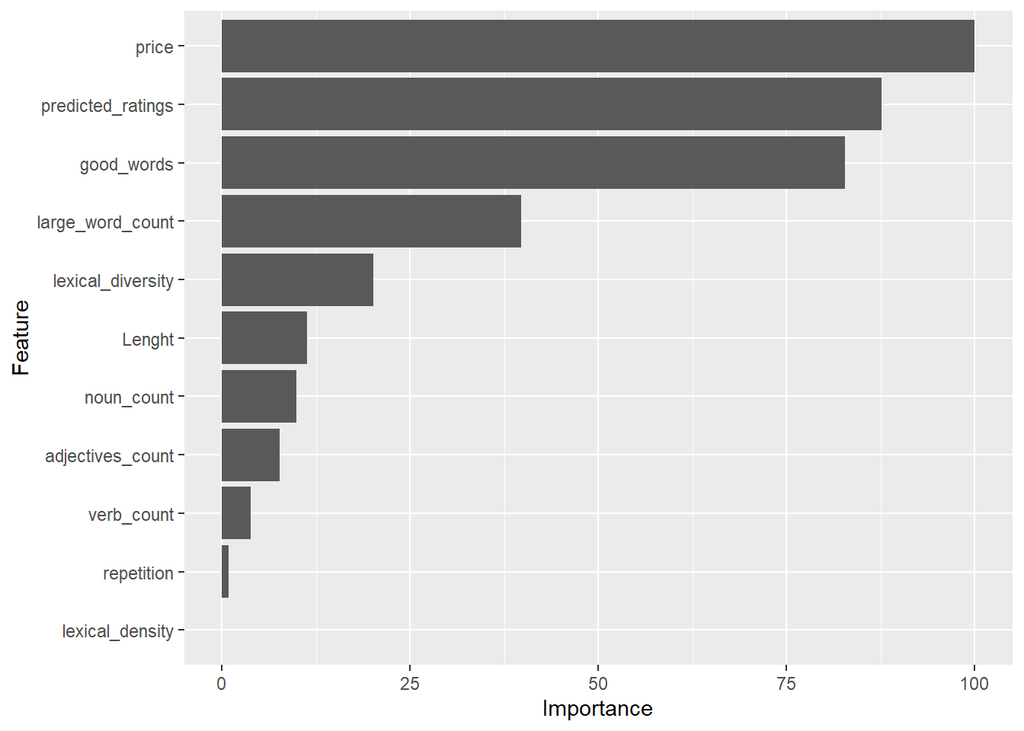

```r
varImp(glm_trained) %>% ggplot()
```

Unsurprisingly, price takes the first position, and the second position goes to our linear model predictions. Then, as we would have expected, the presence of words that are commonly associated with high ratings comes in third. The importance drops significantly after that.

These results are encouraging. They mean that with a limited analysis of the descriptions, one can predict the rating that a wine would get within ~2 points, which is one full point better than just predicting the average of 88.42.

##Conclusion

We started this paper by stating the motivation for this project: we love wine, and we rely on points systems to help us guide our buying.

By looking at the data, we’ve noticed that price was certainly a good indicater of how well a bottle would be rated. However, we had no way of establishing causality.

We then dove into a linear model that took into consideration Country, Taster, Vintage, Winery, Variety and Province variables to predict the scores. We managed to improve our RMSE by 22.89%.

Then, we trained a linear regression algorithm on the data and managed to further improve our RMSE by 12.17%, for a total of 32.27%.

The most important variable in the regression was price, followed by our predicted values from our linear model, and finally by the presence of key words that are often associated with good wine.

```r
library(dplyr)
library(ggplot2)
library(stringr)
library(wordcloud)
library(tidyverse)
library(tidytext)
library(stringr)
library(tm)
library(SnowballC)
library(elasticnet)
library(caret)
#install.packages(quanteda)
#library(quanteda)
```

Reading Dataset

```r
wine = read.csv("D:/Individual Project/winemag-data-130k-v2.csv")
glimpse(wine)
```

```
## Observations: 129,971
## Variables: 14
## $ X                     <int> 0, 1, 2, 3, 4, 5, 6, 7, 8, 9, 10, 11, 12...
## $ country               <fct> Italy, Portugal, US, US, US, Spain, Ital...
## $ description           <fct> "Aromas include tropical fruit, broom, b...
## $ designation           <fct> VulkÃ  Bianco, Avidagos, , Reserve Late ...
## $ points                <int> 87, 87, 87, 87, 87, 87, 87, 87, 87, 87, ...
## $ price                 <dbl> NA, 15, 14, 13, 65, 15, 16, 24, 12, 27, ...
## $ province              <fct> Sicily & Sardinia, Douro, Oregon, Michig...
## $ region_1              <fct> Etna, , Willamette Valley, Lake Michigan...
## $ region_2              <fct> , , Willamette Valley, , Willamette Vall...
## $ taster_name           <fct> Kerin Oâ€™Keefe, Roger Voss, Paul Gregut...
## $ taster_twitter_handle <fct> @kerinokeefe, @vossroger, @paulgwineÂ , ...
## $ title                 <fct> Nicosia 2013 VulkÃ  Bianco  (Etna), Quin...
## $ variety               <fct> White Blend, Portuguese Red, Pinot Gris,...
## $ winery                <fct> Nicosia, Quinta dos Avidagos, Rainstorm,...
```

Creating New Dataset

```r
# create a new variable vintage year by extracting from title
wine$title = as.character(wine$title)
# Regex for extracting year
vintage_patt = "([1|2]{1}[0|9]{1}[0-9]{2})"
y = str_extract_all(wine$title, pattern = vintage_patt, simplify = TRUE)
y = as.data.frame(apply(y, 1:2, as.numeric))
y[is.na(y)] = 0
m = as.matrix(apply(y, 1, max))
y = cbind(y, m)
colnames(y) = c("a","s","d")
y = y %>% mutate(f = ifelse(d>2019, a, d))
y$f[y$f == 0] = NA
wine$vintage = y$f

# create a new dataset removing NA from vintage and vintage before 2000
wine.new = wine %>% filter(!is.na(vintage), vintage > 2000)

# create new variables
wine.new$region = str_c(wine.new$province, wine.new$country, sep = "_")
wine.new$variety_region = str_c(wine.new$variety, wine.new$region, sep = "_")
wine.new$variety_country = str_c(wine.new$variety, wine.new$country, sep = "_")
wine.new$price_range = cut(wine.new$price, c(0,10,20,50,100,500,5000))
wine.new$point_range = cut(wine.new$points, c(80,84,89,94,100))

glimpse(wine.new)
```

```
## Observations: 122,867
## Variables: 20
## $ X                     <int> 0, 1, 2, 3, 4, 5, 6, 7, 8, 9, 10, 11, 12...
## $ country               <fct> Italy, Portugal, US, US, US, Spain, Ital...
## $ description           <fct> "Aromas include tropical fruit, broom, b...
## $ designation           <fct> VulkÃ  Bianco, Avidagos, , Reserve Late ...
## $ points                <int> 87, 87, 87, 87, 87, 87, 87, 87, 87, 87, ...
## $ price                 <dbl> NA, 15, 14, 13, 65, 15, 16, 24, 12, 27, ...
## $ province              <fct> Sicily & Sardinia, Douro, Oregon, Michig...
## $ region_1              <fct> Etna, , Willamette Valley, Lake Michigan...
## $ region_2              <fct> , , Willamette Valley, , Willamette Vall...
## $ taster_name           <fct> Kerin Oâ€™Keefe, Roger Voss, Paul Gregut...
## $ taster_twitter_handle <fct> @kerinokeefe, @vossroger, @paulgwineÂ , ...
## $ title                 <chr> "Nicosia 2013 VulkÃ  Bianco  (Etna)", "Q...
## $ variety               <fct> White Blend, Portuguese Red, Pinot Gris,...
## $ winery                <fct> Nicosia, Quinta dos Avidagos, Rainstorm,...
## $ vintage               <dbl> 2013, 2011, 2013, 2013, 2012, 2011, 2013...
## $ region                <chr> "Sicily & Sardinia_Italy", "Douro_Portug...
## $ variety_region        <chr> "White Blend_Sicily & Sardinia_Italy", "...
## $ variety_country       <chr> "White Blend_Italy", "Portuguese Red_Por...
## $ price_range           <fct> NA, "(10,20]", "(10,20]", "(10,20]", "(5...
## $ point_range           <fct> "(84,89]", "(84,89]", "(84,89]", "(84,89...
```

```r
# text processing

wine.new$doc_id = c(1:nrow(wine.new))
wine.new$text = as.character(wine.new$description)
wine.new= wine.new[c(21,22,1:20)]


# clean and process description data
wine_stopwords = c("will","malbec","gris","made","-","vineyard","riesling","pinot", "noir","chardonnay","zinfandel","delivers","character","texture","well","cabernet","merlot","sauvignon","fruit","fruits","now","drink","palate","offers","shows","wine","winery", "vintage","where", "when","finish","and", "but","flavors","flavor","aroma","aromas","taste","tastes","nose","note","notes")
wine_stopwords.df = data.frame(wine_stopwords,"Custom")
colnames(wine_stopwords.df) = c("word","lexicon")
custom_stopwords = rbind(stop_words,wine_stopwords.df)
wine.new$text = tolower(wine.new$text)

tokenized.df = wine.new %>%
  select(doc_id, text, description, region, variety, vintage, title, variety_region, variety_country) %>%
  unnest_tokens(word, text) %>%
  anti_join(custom_stopwords) %>%
  filter(!str_detect(word, "[0-9]"))
bigram.df = wine.new %>%
  select(doc_id, text, description, region, variety, vintage, title, variety_region, variety_country) %>%
  unnest_tokens(bigram, text, token = "ngrams", n = 2) %>%
  separate(bigram, c("word1", "word2"), sep = " ") %>%
  filter(!word1 %in% custom_stopwords$word,
         !word2 %in% custom_stopwords$word,
         !str_detect(word1, "[0-9]"),
         !str_detect(word2, "[0-9]")) %>%
  unite(bigram, word1, word2, sep = " ")
```

```r
top_variety_region = wine.new %>% na.omit() %>% group_by(variety_region) %>% filter(vintage >= 2000) %>%
  summarise(n=n()) %>% arrange(desc(n)) %>% top_n(12,n) %>% select(variety_region)
```

```r
tf_idf_words <- tokenized.df %>%
  group_by(variety_region,word) %>%
  tally() %>%
  bind_tf_idf(word, variety_region, n) %>%
  arrange(desc(tf_idf))
tf_idf_words
```

| variety_region | word | n | tf | idf | tf_idf |
| --- | --- | --- | --- | --- | --- |
| Sauvignon Blanc_New South Wales_Australia | lion | 1 | 0.25000000 | 7.5840106 | 1.8960026 |
| Sauvignon Blanc_New South Wales_Australia | nathan | 1 | 0.25000000 | 6.8908634 | 1.7227159 |
| Sauvignon Blanc_New South Wales_Australia | usa | 1 | 0.25000000 | 4.6135961 | 1.1533990 |
| GewÃ¼rztraminer-Riesling_Tejo_Portugal | concocted | 1 | 0.14285714 | 7.1785455 | 1.0255065 |
| Tannat_Washington_US | volatiles | 1 | 0.14285714 | 6.0799332 | 0.8685619 |
| Sauvignon Blanc_Kumeu_New Zealand | kumeu | 1 | 0.11111111 | 7.5840106 | 0.8426678 |
| Sauvignon Blanc_New South Wales_Australia | imported | 1 | 0.25000000 | 3.2402052 | 0.8100513 |
| Å½ilavka_Tikves_Macedonia | å | 1 | 0.09090909 | 8.2771578 | 0.7524689 |
| Å½ilavka_Tikves_Macedonia | ilavka | 1 | 0.09090909 | 8.2771578 | 0.7524689 |
| Bordeaux-style Red Blend_France Other_France | franc.this | 1 | 0.09090909 | 8.2771578 | 0.7524689 |

[output cut: 9990 more lines]

```r
tf_idf_bigrams <- bigram.df %>%
  filter(variety_region %in% unname(unlist(top_variety_region))) %>%
  group_by(variety_region,bigram) %>%
  tally() %>%
  bind_tf_idf(bigram, variety_region, n) %>%
  arrange(desc(tf_idf))
tf_idf_bigrams
```

| variety_region | bigram | n | tf | idf | tf_idf |
| --- | --- | --- | --- | --- | --- |
| Chardonnay_Burgundy_France | ripe yellow | 123 | 1.200586e-02 | 1.79175947 | 0.0215116071 |
| Bordeaux-style Red Blend_Bordeaux_France | barrel sample | 433 | 1.928215e-02 | 1.09861229 | 0.0211836089 |
| Bordeaux-style Red Blend_Bordeaux_France | dark tannins | 146 | 6.501603e-03 | 2.48490665 | 0.0161558769 |
| Bordeaux-style Red Blend_Bordeaux_France | chã teau | 235 | 1.046491e-02 | 1.38629436 | 0.0145074446 |
| Bordeaux-style Red Blend_Bordeaux_France | wood aging | 369 | 1.643213e-02 | 0.87546874 | 0.0143858196 |
| Chardonnay_Burgundy_France | wood aging | 160 | 1.561737e-02 | 0.87546874 | 0.0136725230 |
| Bordeaux-style Red Blend_Bordeaux_France | dry core | 159 | 7.080513e-03 | 1.79175947 | 0.0126865762 |
| Bordeaux-style Red Blend_Bordeaux_France | black currant | 930 | 4.141432e-02 | 0.28768207 | 0.0119141578 |
| Sangiovese_Tuscany_Italy | blue flower | 210 | 8.543879e-03 | 1.38629436 | 0.0118443312 |
| Chardonnay_Burgundy_France | green plum | 64 | 6.246950e-03 | 1.79175947 | 0.0111930313 |

[output cut: 9990 more lines]

```r
# create a sample dataset

top_variety_region_model = wine.new %>% na.omit() %>% group_by(variety_region) %>% filter(vintage >= 2000) %>%
  summarise(n=n()) %>% arrange(desc(n)) %>% top_n(10,n) %>% select(variety_region)

set.seed(1234)
wine.s = wine.new %>% filter(variety_region %in% unname(unlist(top_variety_region_model))) %>% sample_n(20000)
```

```r
# create a 70/30% train/test dataset split

#install.packages('caret')
library(caret)

set.seed(12)
indexes = createDataPartition(wine.s$variety_region, times = 1, p = 0.7, list = FALSE)
train = wine.s[indexes,] %>% arrange(doc_id)
test = wine.s[-indexes,] %>% arrange(doc_id)
train %>% count(variety_region, sort = T)
```

| variety_region | n |
| --- | --- |
| Pinot Noir_California_US | 2669 |
| Cabernet Sauvignon_California_US | 2114 |
| Chardonnay_California_US | 2014 |
| Bordeaux-style Red Blend_Bordeaux_France | 1736 |
| Pinot Noir_Oregon_US | 1061 |
| Nebbiolo_Piedmont_Italy | 1050 |
| Zinfandel_California_US | 922 |
| Chardonnay_Burgundy_France | 884 |
| Red Blend_Tuscany_Italy | 859 |
| Syrah_California_US | 695 |

```r
#install.packages('quanteda')
library(quanteda)
# tokenize and process text
train.tokens = tokens(train$text, what = "word",
                      remove_numbers = TRUE, remove_punct = TRUE,
                      remove_symbols = TRUE, remove_hyphens = TRUE)
train.tokens = tokens_tolower(train.tokens)
train.tokens = tokens_select(train.tokens, custom_stopwords,
                             selection = "remove")
train.tokens = tokens_wordstem(train.tokens, language = "english")
train.tokens.dfm = dfm(train.tokens, tolower = FALSE)
train.tokens.dfm = dfm_trim(train.tokens.dfm, sparsity = 0.99)
train.tokens.matrix = as.matrix(train.tokens.dfm)
train.tokens.df = cbind(Label = train$variety_region, convert(train.tokens.dfm, to = 'data.frame'))
```

```r
# tfidf
term.frequency <- function(row) {
  row / sum(row)
}

inverse.doc.freq <- function(col) {
  corpus.size <- length(col)
  doc.count <- length(which(col > 0))

  log10(corpus.size / doc.count)
}

tf.idf <- function(x, idf) {
  x * idf
}
train.tokens.df = apply(train.tokens.matrix, 1, term.frequency)
train.tokens.idf = apply(train.tokens.matrix, 2, inverse.doc.freq)
train.tokens.tfidf = apply(train.tokens.df, 2, tf.idf, idf = train.tokens.idf)
train.tokens.tfidf = t(train.tokens.tfidf)
incomplete.cases = which(!complete.cases(train.tokens.tfidf))
train.tokens.tfidf[incomplete.cases] = rep(0.0, ncol(train.tokens.tfidf))
train.tokens.tfidf.df = cbind(Label = train$variety_region, data.frame(train.tokens.tfidf))
```

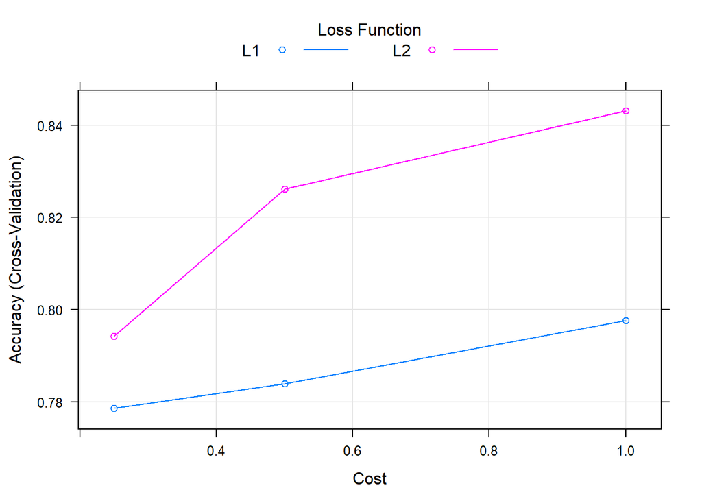

```r
# train model with linear SVM and 10-fold Cross Validation
#install.packages(e1071)
library(e1071)
library(LiblineaR)
library(caret)
cv.cntrl = trainControl(method = "cv", number = 10)

token_model_svm = train(Label~., data = train.tokens.tfidf.df, method = 'svmLinear3', trControl = cv.cntrl)
plot(token_model_svm)
```

```r
#token_model_svm$finalModel
```

```r
# process test data - test dataset needs to have the same structure as train dataset

test.tokens = tokens(test$text, what = "word",
                     remove_numbers = TRUE, remove_punct = TRUE,
                     remove_symbols = TRUE, remove_hyphens = TRUE)
test.tokens = tokens_tolower(test.tokens)
test.tokens = tokens_select(test.tokens, custom_stopwords,
                            selection = "remove")
test.tokens = tokens_wordstem(test.tokens, language = "english")
test.tokens.dfm = dfm(test.tokens, tolower = FALSE)
test.tokens.dfm = dfm_select(test.tokens.dfm, pattern = train.tokens.dfm,
                             selection = "keep")
test.tokens.matrix = as.matrix(test.tokens.dfm)

test.tokens.df <- apply(test.tokens.matrix, 1, term.frequency)
test.tokens.tfidf <-  apply(test.tokens.df, 2, tf.idf, idf = train.tokens.idf)

test.tokens.tfidf <- t(test.tokens.tfidf)
test.tokens.tfidf[is.na(test.tokens.tfidf)] <- 0.0
test.tokens.tfidf.df = cbind(Label = test$variety_region, data.frame(test.tokens.tfidf))

result = predict(token_model_svm, newdata = test.tokens.tfidf.df)
#confusionMatrix(result, test.tokens.tfidf.df$Label)
```

```r
# wine recommendation - cosine similarity
library(dplyr)
library(tidytext)
library(stringr)
token.sample = wine.s %>%
  select(doc_id, text, description, region, variety, vintage, title, variety_region, variety_country) %>%
  unnest_tokens(word, text) %>%
  anti_join(custom_stopwords) %>%
  filter(!str_detect(word, "[0-9]")) %>%
  mutate(word = SnowballC::wordStem(word))
tfidf.s = token.sample %>%
  count(title,word, sort = TRUE) %>%
  bind_tf_idf(word, title, n)

sparse.matrix = tfidf.s%>%
  cast_sparse(title, word, tf_idf)
```

```r
#install.packages('text2vec')
library(text2vec)
similarities = sim2(sparse.matrix, method = "cosine", norm = "l2")

get_similar_wine  = function(similarities, reference_wine, n_recommendations = 3){
  sort(similarities[reference_wine, ], decreasing = TRUE)[1:(2 + n_recommendations)]
}

get_similar_wine(similarities, 10000)
```

```
##                         Copain Wines 2009 Wentzel Pinot Noir (Anderson Valley)
##                                                                      1.0000000
##                      Handley 2006 Estate Vineyard Chardonnay (Anderson Valley)
##                                                                      0.2842888
##                   Foursight 2007 Charles Vineyard Pinot Noir (Anderson Valley)
##                                                                      0.2703662
##                                         Kalaris 2010 Pinot Noir (Sonoma Coast)
##                                                                      0.2614793
## TreViti 2006 Stolo Family Vineyard Anno di Isabella Pinot Noir (Central Coast)
##                                                                      0.2611557
```

```r
get_similar_wine(similarities, 2000)
```

```
##                  ChÃ¢teau Pichon Longueville 2007  Pauillac
##                                                   1.0000000
## Blue Rock 2005 Estate Cabernet Sauvignon (Alexander Valley)
##                                                   0.3219388
##                       ChÃ¢teau Brane-Cantenac 2007  Margaux
##                                                   0.3006264
##                  ChÃ¢teau Moulin Haut-Laroque 2015  Fronsac
##                                                   0.2905448
##                      ChÃ¢teau Tour de Luchey 2009  Bordeaux
##                                                   0.2882533
```